# Video Games Data Analysis

[figure not shown]

Photo by [Sean Stone](https://unsplash.com/@seanstonephotography?utm_source=unsplash&utm_medium=referral&utm_content=creditCopyText) on [Unsplash](https://unsplash.com/s/photos/video-games?utm_source=unsplash&utm_medium=referral&utm_content=creditCopyText)

## 1. Preparations

### 1.1. Packages

Loading relevant **packages**

```r
library(rmarkdown)
library(tidyverse)
library(readr)
library(gganimate)
library(lubridate)
library(dplyr)
library(VIM)
library(gganimate)
library(gifski)
library(RColorBrewer)
library(knitr)
```

## 2. Loading and Preparing the Data

The data set comes from Kaggle and includes the **number of sold copies in million** for Videos Games from **1980 to 2020**. For each Video Game we have also information about the Genre, the Publisher and the Platform as well as the rank regarding to the Global Sales. The **Global Sales** (in video games) is the **sum of the sold video games** from **North America** (NA_Sales), **Europe** (EU_Sales), **Japan** (JP_Sales) and **others** (Other_Sales). The data set contains 16,598 rows.

```
## Rows: 16,598
## Columns: 11
## $ Rank         <dbl> 1, 2, 3, 4, 5, 6, 7, 8, 9, 10, 11, 12, 13, 14, 15, 16, 17…
## $ Name         <chr> "Wii Sports", "Super Mario Bros.", "Mario Kart Wii", "Wii…
## $ Platform     <chr> "Wii", "NES", "Wii", "Wii", "GB", "GB", "DS", "Wii", "Wii…
## $ Year         <chr> "2006", "1985", "2008", "2009", "1996", "1989", "2006", "…
## $ Genre        <chr> "Sports", "Platform", "Racing", "Sports", "Role-Playing",…
## $ Publisher    <chr> "Nintendo", "Nintendo", "Nintendo", "Nintendo", "Nintendo…
## $ NA_Sales     <dbl> 41.49, 29.08, 15.85, 15.75, 11.27, 23.20, 11.38, 14.03, 1…
## $ EU_Sales     <dbl> 29.02, 3.58, 12.88, 11.01, 8.89, 2.26, 9.23, 9.20, 7.06, …
## $ JP_Sales     <dbl> 3.77, 6.81, 3.79, 3.28, 10.22, 4.22, 6.50, 2.93, 4.70, 0.…
## $ Other_Sales  <dbl> 8.46, 0.77, 3.31, 2.96, 1.00, 0.58, 2.90, 2.85, 2.26, 0.4…
## $ Global_Sales <dbl> 82.74, 40.24, 35.82, 33.00, 31.37, 30.26, 30.01, 29.02, 2…
```

The **description** in a short overview:

| variable | description |
| --- | --- |
| Rank | The rank of the video game, determined by global sales |
| Name | The name of the video game |
| Platform | The platform the video game was published on |
| Year | The year the video game was published |
| Genre | The genre of the video game |
| Publisher | The publisher of the video game |
| NA_Sales | The number of sales of the video game in North America |
| EU_Sales | The number of sales of the video game in Europe |
| JP_Sales | The number of sales of the video game in Japan |
| Other_Sales | The number of sales of the video game in other parts of the world |
| Global_Sales | The total number of sales of the video game |

As the glimpse of data showed, we need to **transform** some of the data. We need “Year” as an **integer**, as well as “Platform”, “Genre” and “Publisher” as **factor**:

```r
data$Year <- as.integer(data$Year)
data$Platform <- as.factor(data$Platform)
data$Genre <- as.factor(data$Genre)
data$Publisher <- as.factor(data$Publisher)
glimpse(data)
```

```
## Rows: 16,598
## Columns: 11
## $ Rank         <dbl> 1, 2, 3, 4, 5, 6, 7, 8, 9, 10, 11, 12, 13, 14, 15, 16, 17…
## $ Name         <chr> "Wii Sports", "Super Mario Bros.", "Mario Kart Wii", "Wii…
## $ Platform     <fct> Wii, NES, Wii, Wii, GB, GB, DS, Wii, Wii, NES, DS, DS, GB…
## $ Year         <int> 2006, 1985, 2008, 2009, 1996, 1989, 2006, 2006, 2009, 198…
## $ Genre        <fct> Sports, Platform, Racing, Sports, Role-Playing, Puzzle, P…
## $ Publisher    <fct> "Nintendo", "Nintendo", "Nintendo", "Nintendo", "Nintendo…
## $ NA_Sales     <dbl> 41.49, 29.08, 15.85, 15.75, 11.27, 23.20, 11.38, 14.03, 1…
## $ EU_Sales     <dbl> 29.02, 3.58, 12.88, 11.01, 8.89, 2.26, 9.23, 9.20, 7.06, …
## $ JP_Sales     <dbl> 3.77, 6.81, 3.79, 3.28, 10.22, 4.22, 6.50, 2.93, 4.70, 0.…
## $ Other_Sales  <dbl> 8.46, 0.77, 3.31, 2.96, 1.00, 0.58, 2.90, 2.85, 2.26, 0.4…
## $ Global_Sales <dbl> 82.74, 40.24, 35.82, 33.00, 31.37, 30.26, 30.01, 29.02, 2…
```

Now, we can see, that we have **missing values** for some years.

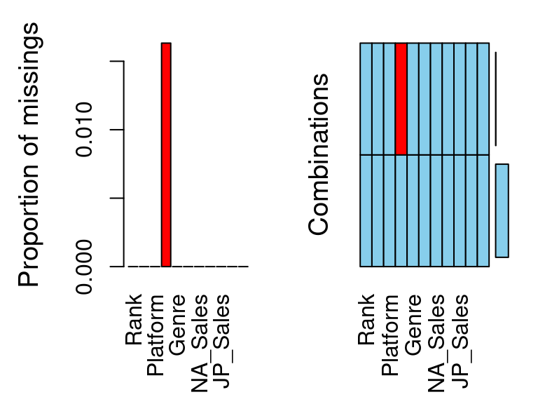

```r
aggr(data)
```

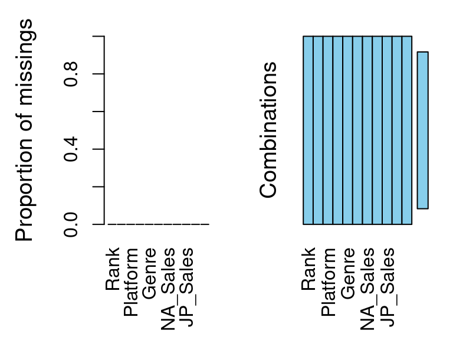

```r
data_clean <- data %>% drop_na()
aggr(data_clean)
```

## 3. Graphs

### 3.1 Sales by Year

With all these data, we try to get an overview and **group the data by “Year”**. For each year, the sold video games, is the sum.

```r
Sales_Year<-data_clean %>% group_by(Year) %>% summarise(Global_Sales_Year = sum(Global_Sales),
                                                        Other_Sales_Year = sum(Other_Sales),
                                                        Japan_Sales_Year = sum(JP_Sales),
                                                        NorthAmerica_Sales_Year = sum(NA_Sales),
                                                        Europe_Sales_Year = sum(EU_Sales))
head(Sales_Year)
```

| Year | Global_Sales_Year | Other_Sales_Year | Japan_Sales_Year | NorthAmerica_Sales_Year | Europe_Sales_Year |
| --- | --- | --- | --- | --- | --- |
| 1980 | 11.38 | 0.12 | 0.00 | 10.59 | 0.67 |
| 1981 | 35.77 | 0.32 | 0.00 | 33.40 | 1.96 |
| 1982 | 28.86 | 0.31 | 0.00 | 26.92 | 1.65 |
| 1983 | 16.79 | 0.14 | 8.10 | 7.76 | 0.80 |
| 1984 | 50.36 | 0.70 | 14.27 | 33.28 | 2.10 |
| 1985 | 53.94 | 0.92 | 14.56 | 33.73 | 4.74 |

```r
SalesByYear<- Sales_Year %>% ggplot() +
    geom_line(mapping=aes(x=Year, y=Global_Sales_Year, col="Global")) +
    geom_line(mapping=aes(x=Year,y=Other_Sales_Year, col="Other"))+
    geom_line(mapping=aes(x=Year,y=Japan_Sales_Year, col="Japan"))+
    geom_line(mapping=aes(x=Year,y=NorthAmerica_Sales_Year, col="NorthAmerica"))+
    geom_line(mapping=aes(x=Year,y=Europe_Sales_Year, col="Europe"))+
    scale_color_manual(name="Region", values=c("Global"="deeppink3","Other"="coral2","Japan"="darkolivegreen",
                                "NorthAmerica"="darkcyan", "Europe"="darkseagreen"))+
   ggtitle("Sold Games by Region") +
    ylab("Sold Games (in million copies)")+
    theme_bw() +
      theme(
    plot.title = element_text(face = "bold", size = 12, hjust = 0.5),
          axis.text = element_text(size = 9),
    legend.background = element_rect(fill = "white", size = 4, colour = "white"),
    #legend.justification = c(0, 1),
    legend.position = c(0.125, 0.75),
    axis.ticks = element_line(colour = "grey70", size = 0.2),
    panel.grid.major = element_line(colour = "grey70", size = 0.2),
    panel.grid.minor = element_blank()
      )+
      transition_reveal(Year)
```

```r
animate(SalesByYear, res = 69)
anim_save("SalesByYear.gif", animation = last_animation(), path = NULL)
```

[figure not shown]

```r
include_graphics("SalesByYear.gif")
```

### 3.1 Platforms by Regional Sales and Year

Next, we will take a deeper look into the different platforms. First, we transform the **data to a long** version. We *add the column “Sales_Region”* which is the **amount of video games** (in million) **sold for the region specified in “Sales_Type”** - the second column we added.

```r
head(data_clean_long)
```

| Rank | Name | Platform | Year | Genre | Publisher | Sales_Type | Sales_Region |
| --- | --- | --- | --- | --- | --- | --- | --- |
| 1 | Wii Sports | Wii | 2006 | Sports | Nintendo | Other_Sales | 8.46 |
| 1 | Wii Sports | Wii | 2006 | Sports | Nintendo | JP_Sales | 3.77 |
| 1 | Wii Sports | Wii | 2006 | Sports | Nintendo | NA_Sales | 41.49 |
| 1 | Wii Sports | Wii | 2006 | Sports | Nintendo | EU_Sales | 29.02 |
| 1 | Wii Sports | Wii | 2006 | Sports | Nintendo | Global_Sales | 82.74 |
| 2 | Super Mario Bros. | NES | 1985 | Platform | Nintendo | Other_Sales | 0.77 |

Now we can plot a **bar chart** with all **Platforms** including the **different types of Sales** (for each region). Since we do not want to look at one specific year, we plot all at ones.

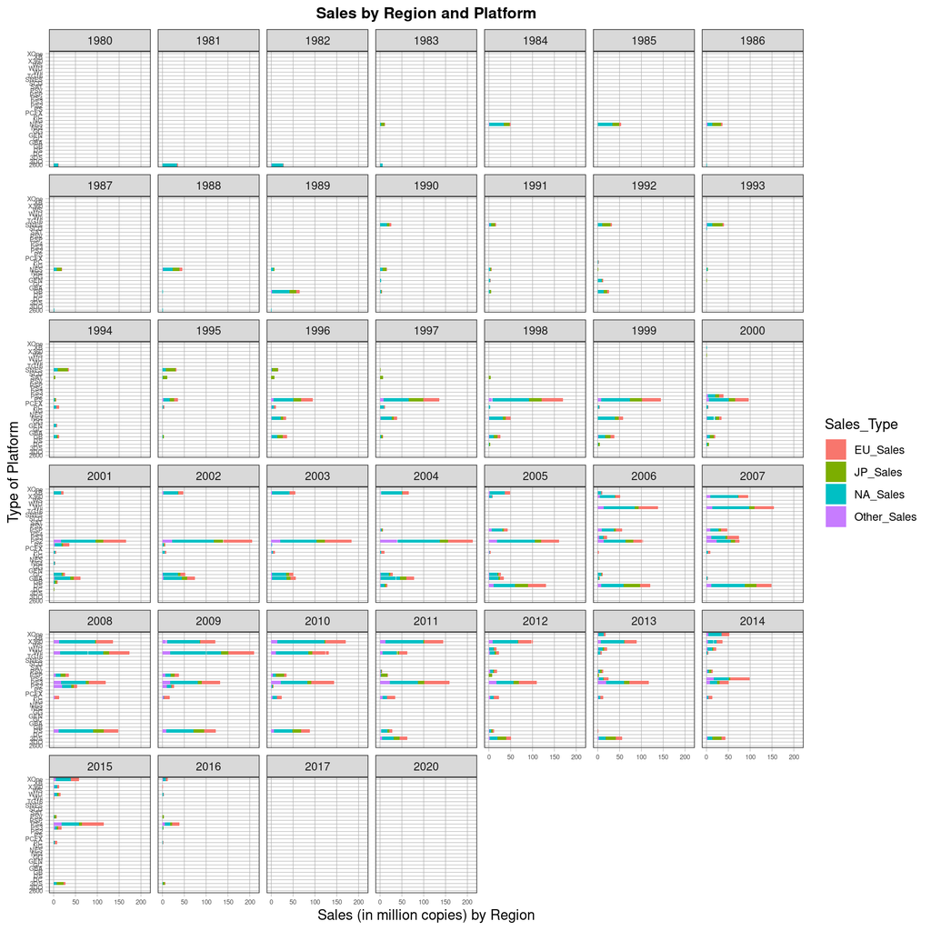

```r
PlatformByYear <- data_clean_long %>% filter(Sales_Type!="Global_Sales")  %>%
    ggplot(aes(fill=Sales_Type, x=Platform, y=Sales_Region))+
    geom_bar(position="stack", stat="identity") +
        ggtitle("Sales by Region and Platform") +
        ylab("Sales (in million copies) by Region")+
        xlab("Type of Platform")+
        coord_flip()+
    theme_bw() +
      theme(
        plot.title = element_text(face = "bold", size = 12, hjust = 0.5),
        axis.text = element_text(size = 5),
        axis.ticks = element_line(colour = "grey70", size = 0.2),
        panel.grid.major = element_line(colour = "grey70", size = 0.2),
        panel.grid.minor = element_blank()
          ) + facet_wrap(~ Year)
PlatformByYear
```